# Portfolio Risk–Return Analysis of Selected JSE Stocks

**Author:** Monya Cisternas  
**Date:** February 2026  
**Objective:** Evaluate historical performance and identify the optimal risk-adjusted portfolio allocation.

## Executive Summary

Key objectives:

- Compare individual stock performance
- Measure risk using standard deviation
- Analyse correlations between assets
- Simulate portfolio allocations
- Identify the portfolio with the highest Sharpe ratio

The goal is to determine whether diversification improves risk-adjusted returns relative to holding a single asset.

## Business Problem

Investors must balance expected return against volatility.  
Holding a single high-return stock may expose an investor to excessive risk.

This analysis explores whether combining assets across sectors (financials, retail, resources, and global tech exposure) improves portfolio stability and maximises risk-adjusted performance.

```
[*********************100%***********************]  5 of 5 completed
```

## Data Overview

The dataset contains daily adjusted closing prices for each selected stock. Adjusted prices account for dividends and stock splits, making them suitable for total return analysis.

[output not shown]

| Ticker | AGL.JO | FSR.JO | PRX.JO | SHP.JO | SOL.JO |
| --- | --- | --- | --- | --- | --- |
| count | 1326.000000 | 1326.000000 | 1326.000000 | 1326.000000 | 1326.000000 |
| mean | 52442.507444 | 6108.259679 | 60267.431069 | 20022.162363 | 21913.694329 |
| std | 11178.611196 | 1135.642249 | 11502.000197 | 5977.685725 | 8509.480432 |
| min | 20602.863281 | 3378.772461 | 31634.068359 | 10012.396484 | 2185.266846 |
| 25% | 42851.330078 | 5477.398071 | 53063.999023 | 13898.250732 | 14096.030518 |
| 50% | 53589.796875 | 6264.215332 | 60895.279297 | 21259.180664 | 23074.265625 |
| 75% | 59503.602539 | 6727.905518 | 67378.701172 | 24481.319824 | 27664.897461 |
| max | 81421.523438 | 8681.484375 | 88903.789062 | 31443.160156 | 42988.234375 |

## Exploratory Data Analysis (EDA)

| Ticker | AGL.JO | FSR.JO | PRX.JO | SHP.JO | SOL.JO |
| --- | --- | --- | --- | --- | --- |
| count | 1325.000000 | 1325.000000 | 1325.000000 | 1325.000000 | 1325.000000 |
| mean | 0.000705 | 0.000381 | 0.000554 | 0.000846 | 0.000076 |
| std | 0.026036 | 0.021017 | 0.025502 | 0.018798 | 0.044381 |
| min | -0.133194 | -0.142791 | -0.173925 | -0.099922 | -0.465627 |
| 25% | -0.013320 | -0.010098 | -0.012099 | -0.009392 | -0.019197 |
| 50% | 0.000740 | 0.000656 | -0.000209 | -0.000035 | -0.001077 |
| 75% | 0.014768 | 0.011068 | 0.012680 | 0.009765 | 0.016343 |
| max | 0.189202 | 0.137758 | 0.210721 | 0.136302 | 0.534834 |

### Average Annual Returns

The average annual returns indicate differences in long-term performance across the selected JSE stocks.

- **SHP.JO (21.33%)** delivered the highest average annual return, suggesting strong historical growth over the selected period.
- **AGL.JO (17.78%)** demonstrated solid performance, likely reflecting its exposure to global commodity cycles.
- **PRX.JO (13.97%)** showed moderate growth that is consistent with its international tech exposure.
- **FSR.JO (9.61%)** produced steady but comparatively lower returns, typical of a large financial institution.
- **SOL.JO (1.91%)** underperformed significantly compared to other assets. This indicates weak historical growth during the selected period.

Retail and resource exposure from SHP.JO and AGL.JO appear to have generated the strongest returns, while energy (SOL.JO) contributed the least.

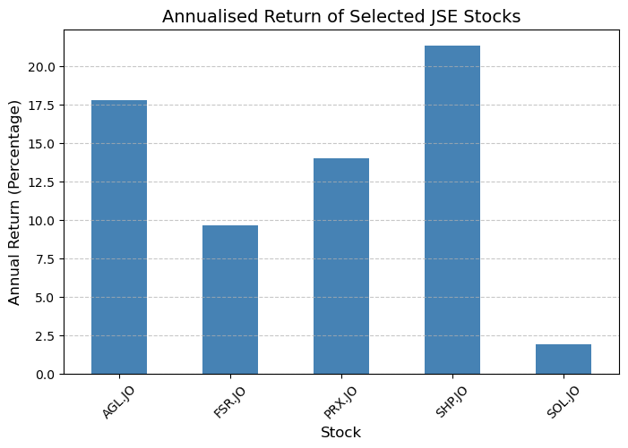

### Annual Volatility

- **SOL.JO (70.45%)** shows extremely high volatility, indicating significant price fluctuations and high risk exposure.
- **AGL.JO (41.33%) and PRX.JO (40.48%)** show relatively high risk, reflecting sensitivity to global commodity and tech market movements.
- **FSR.JO (33.36%)** reflects moderate risk, consistent with the exposure in large-cap financial sectors.
- **SHP.JO (29.84%)** exhibits stable price behaviour, as shown in its lower volatility.

Financial and retail exposures provide lower risk profiles compared to energy and resource-linked assets.

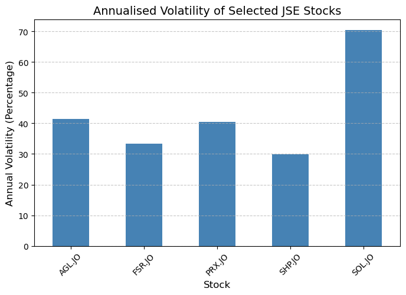

## Risk/Return Comparative Analysis

A comparison of annualised volatility and returns to identify attractiveness of selected stocks.

- **SHP.JO (Return: 21.33%, Risk: 29.84%)** presents the most attractive standalone profile with the highest return and lowest volatility.
- **AGL.JO (Return: 17.78%, Risk: 41.33%)** materially higher risk with solid return potential.
- **PRX.JO (Return: 13.97%, Risk: 40.48%)** elevated risk with moderate growth potential.
- **FSR.JO (Return: 9.61%, Risk: 33.36%)** moderate risk with steady, although lower growth.
- **SOL.JO (Return: 1.91%, Risk: 70.45%)** minimal return with severely high risk. This profile is the least attractive.

### Key Observations

- SHP.JO is the most efficient asset over the selected period with an attractive risk/return ratio.
- SOL.JO increases portfolio risk significantly without a proportionate return contribution.
- Diversification benefits will depend on correlation structure rather than return alone.

Although individual asset performance is informative, an optimal portfolio construction requires analysing correlation and covariance to determine whether diversification can reduce risks and optimise returns.

**Note:** Volatility scales with the square root of the period due to properties of variance under independent returns.

### Asset Correlation

Diversification benefits arise when correlations between assets are less than 1.

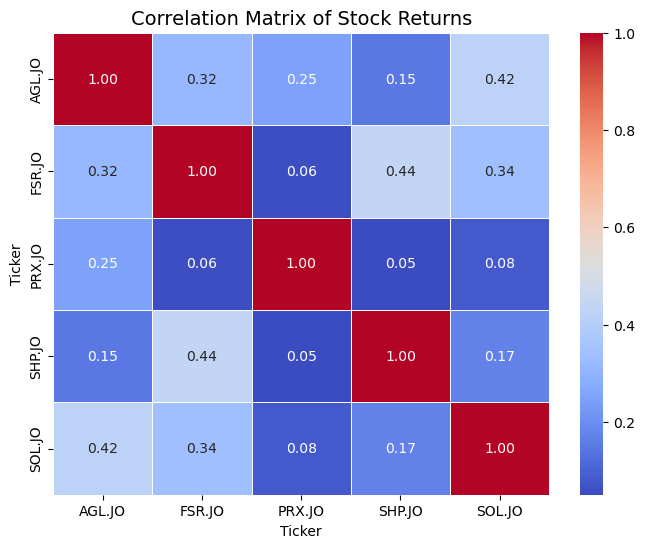

### Covariance Matrix

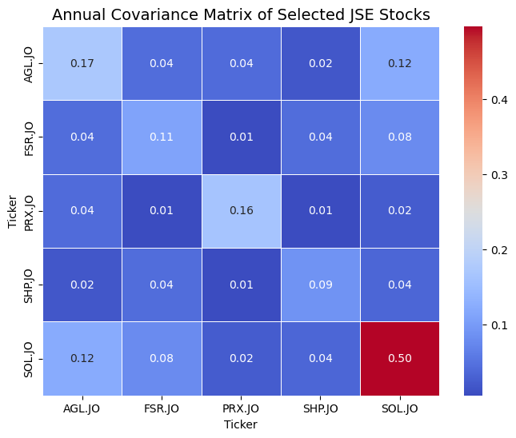

### Portfolio Allocation Simulation

The scatter plot visualizes 5,000 randomly generated portfolios. The red star represents the maximum Sharpe Ratio portfolio with the best risk-adjusted return, and the blue star represents the minimum volatility portfolio with the lowest risk. Color intensity indicates the Sharpe ratio which shows the risk-return trade-off and helps investors choose optimal allocations.

The Sharpe ratio measures return per unit of risk, allowing portfolios to be compared on a risk-adjusted basis rather than raw return alone.

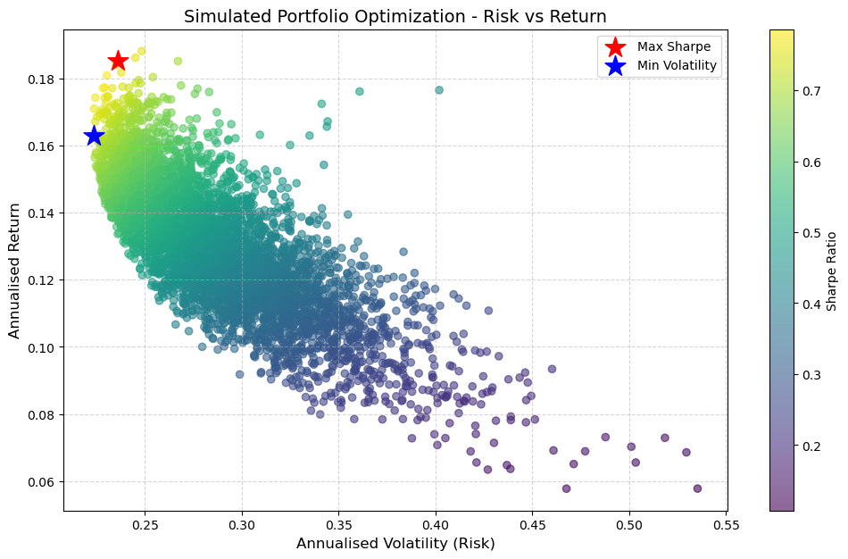

```
Maximum Sharpe Ratio Portfolio
Return        0.185454
Volatility    0.235975
Sharpe        0.785905
AGL.JO        0.292126
FSR.JO        0.003116
PRX.JO        0.210221
SHP.JO        0.486173
SOL.JO        0.008364
Name: 4313, dtype: float64
Minimum Volatility Portfolio
Return        0.162910
Volatility    0.223684
Sharpe        0.728305
AGL.JO        0.165769
FSR.JO        0.226208
PRX.JO        0.218961
SHP.JO        0.379475
SOL.JO        0.009588
Name: 1168, dtype: float64
```

## Conclusion

SHP.JO demonstrated the strongest individual risk–return profile, combining high returns with comparatively low risk. In contrast, SOL.JO exhibited high volatility with very low return contribution, making it less attractive on a risk-adjusted basis.

This outcome reinforces a core principle of portfolio theory: optimal asset allocation depends not only on individual returns but on covariance structure and diversification benefits. Assets that improve overall portfolio efficiency receive higher weight, even if they are not the absolute highest-return assets.

### Limitations

This analysis relies on historical data and assumes return distributions remain stable over time. Market regimes, macroeconomic conditions, and structural changes may alter future performance. Additionally, transaction costs, taxes, and liquidity constraints were not accounted for in the simulation.

### Final Insight

The project demonstrates that disciplined quantitative analysis can transform raw market data into actionable portfolio insights. By focusing on risk-adjusted returns and diversification, investors can construct portfolios that are more efficient than any individual asset.